# Midterm Part 3 - Analysis of Minimum Wage by U.S. Region

Neil Shah

02/08/21

```r
library(tidyverse)
library(here)
```

```r
min_wage <- read_csv(here("Midterm", "Minimum Wage Data.csv"))
```

### Introduction

In this assignment, I am comparing the minimum wage in different regions of the United States over time. Using the provided dataset, I have separated the states into 5 regions: Northwest, Northeast, Southwest, Southeast, and Other. The Northwest region includes Oregon, Washington, Idaho, Montana, Wyoming, North Dakota, South Dakota, Nebraska, Minnesota, and Iowa. Northeast contains Maine, New Hampshire, Vermont, Massachusetts, Rhode Island, Connecticut, New York, New Jersey, Pennsylvania, Delaware, Maryland, Ohio, Illinois, Michigan, Indiana, Wisconsin. Southwest has Missouri, Arkansas, Colorado, Louisiana, Kansas, New Mexico, Oklahoma, Texas, Utah, Nevada, Arizona, and California. Southeast consists of Alabama, Florida, Georgia, Mississippi, North Carolina, South Carolina, Tennessee, Kentucky, Virginia, and West Virginia. Finally, Other has anything not on the mainland including Alaska, Hawaii, Guam, District of Columbia, Puerto Rico, and U.S. Virgin Islands.

```r
region_wage <- min_wage %>%
  mutate(region = fct_collapse(State,
               Northwest = c("Oregon", "Washington", "Idaho", "Montana", "Wyoming", "North Dakota", "South Dakota", "Nebraska", "Minnesota", "Iowa"),
               Northeast = c("Maine", "New Hampshire", "Vermont", "Massachusetts", "Rhode Island", "Connecticut", "New York", "New Jersey", "Pennsylvania", "Delaware", "Maryland", "Ohio", "Illinois", "Michigan", "Indiana", "Wisconsin") ,
               Southwest = c("Missouri", "Arkansas", "Colorado", "Louisiana", "Kansas", "New Mexico", "Oklahoma", "Texas", "Utah", "Nevada", "Arizona", "California") ,
               Southeast = c("Alabama", "Florida", "Georgia", "Mississippi", "North Carolina", "South Carolina", "Tennessee", "Kentucky", "Virginia", "West Virginia"),
               Other = c("Alaska", "Hawaii", "Guam", "District of Columbia", "Puerto Rico", "U.S. Virgin Islands")))
```

### Table

```r
region_wage %>%
  mutate(Year = as.factor(Year)) %>%
  filter(Year %in% c(1970, 1980, 1990, 2000, 2010, 2020)) %>%
  group_by(Year, region) %>%
  summarize(x = mean(Effective.Minimum.Wage.2020.Dollars))
```

```
## # A tibble: 30 × 3
## # Groups:   Year [6]
##    Year  region        x
##    <fct> <fct>     <dbl>
##  1 1970  Southeast  8.67
##  2 1970  Other     10.6
##  3 1970  Southwest  8.86
##  4 1970  Northeast  9.57
##  5 1970  Northwest  8.87
##  6 1980  Southeast  9.73
##  7 1980  Other      9.99
##  8 1980  Southwest  9.73
##  9 1980  Northeast  9.73
## 10 1980  Northwest  9.73
## # … with 20 more rows
```

In the table above, I have calculated the average minimum wage for each different region, by decade. We can see that in the 1970s, the “Other” region had the highest minimum wage with an average of about 10.56 dollars an hour. By the 1980s, the minimum wage in each region of the mainland United States was about 9.73 dollars an hour but the “Other”region still had the highest at 9.99 dollars an hour. In the 1990s, the minimum wage in each mainland region went down to about 6.63 dollars an hour with the “Other”region still at the top with 7.01 dollars an hour. Finally, in the 2000s the Northwest region slightly overtook the “Other” region with a minimum wage of about 8.144 dollars an hour compared to 8.14 dollars per hour respectively. Northeast had the highest minimum wage in the 2010s with a minimum wage of 8.91 dollars per hour, and “Other” reclaimed the top spot in the 2020s with 10.05 dollars an hour.

### Graph 1

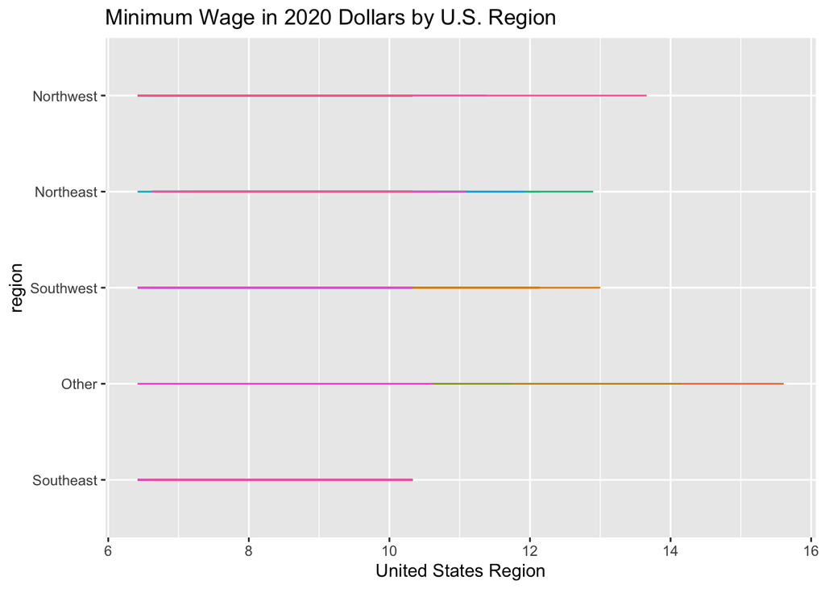

```r
region_wage %>%
  ggplot(mapping = aes(y = region,
                       x = Effective.Minimum.Wage.2020.Dollars)) +
  geom_line(aes(color = State)) +
  labs(title = "Minimum Wage in 2020 Dollars by U.S. Region",
       x = "United States Region",
       x = "Minimum Wage($)") +
  theme(legend.position = "none")
```

In this graph above, we can see the minimum wage in 2020 U.S. dollars by each region. It is evident that the highest minimum wage, close to around 15.50 dollars an hour, was offered in the “Other” region which included all the areas off the mainland. Within the actual United States mainland, the Northwest region had the highest minimum wage of about 13.70 dollars an hour. Following this was Southwest(about 13 dollars an hour), then Northeast(about 12.90 dollars an hour), then Southeast(about 10.20 dollars an hour). However, this is over the entire 50 years included in the dataset, so lets take a look at each decade throughout this half century…

### Graph 2

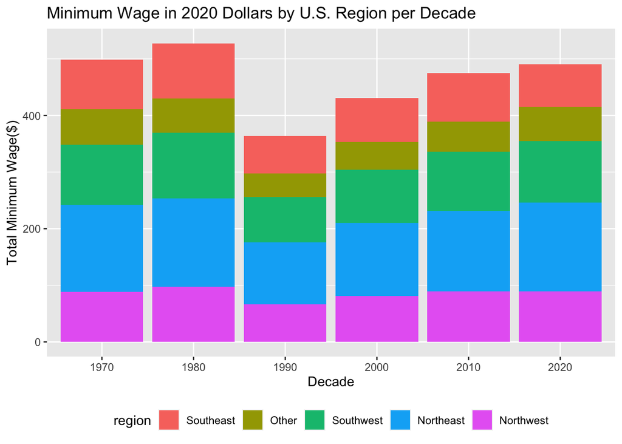

```r
region_wage %>%
  mutate(Year = as.factor(Year)) %>%
  filter(Year %in% c(1970, 1980, 1990, 2000, 2010, 2020)) %>%
  ggplot(mapping = aes(y = Effective.Minimum.Wage.2020.Dollars,
                       x = Year)) +
  geom_col(aes(fill = region)) +
  labs(title = "Minimum Wage in 2020 Dollars by U.S. Region per Decade",
       x = "Decade",
       y = "Total Minimum Wage($)") +
  theme(legend.position = "bottom")
```